# Residualization reinterpretation

Nicholas Judd https://staff.ki.se/people/nicholas-judd (Karolinska Institute)https://ki.se/en

## How standardized effects vary with residualization

The Frisch-Waugh-Lovell theorem states that residualizing all variable in the linear model for a variable (e.g., X2) is equal to adding it as a covariate. Therefore B1 in the two equations are identical:

$$\operatorname{Y} = \alpha + \beta_{1}(\operatorname{X1}) + \beta_{2}(\operatorname{X2}) + \epsilon$$
$$\operatorname{Y_{residualized\_X2}} = \alpha + \beta_{1}(\operatorname{X1_{residualized\_X2}}) + \epsilon$$

### Data simulation

First we simulate data of a 1000 subjects with 3 correlated variables in standard units (mean = 0, sd = 1). Y stands for the dependent variable while X1 & X2 are predictors with a 0.5 correlation.

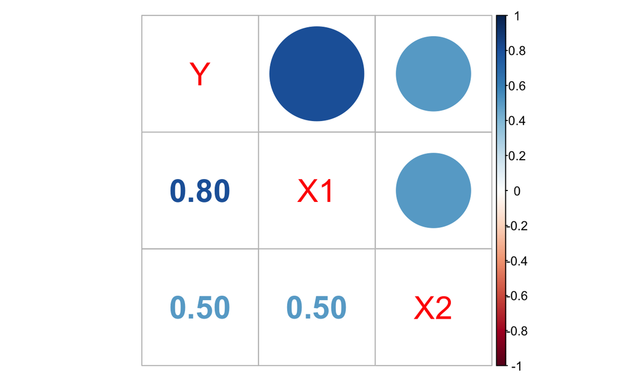

We than make two more variables by extracting the residuals from 1) a model with Y regressed on X2 and 2) a model with X1 regressed on X2. These two variables (i.e., Y_X2res & X1_X2res) by construction are unrelated to X2. We than standardize these variables making (Y_X2res_S & X1_X2res_S).

Table 1: An overview of simluated variables

|  | n | mean | sd |
| --- | --- | --- | --- |
| Y | 1000 | 0 | 1.00 |
| X1 | 1000 | 0 | 1.00 |
| X2 | 1000 | 0 | 1.00 |
| Y_X2res | 1000 | 0 | 0.87 |
| X1_X2res | 1000 | 0 | 0.87 |
| Y_X2res_Scaled | 1000 | 0 | 1.00 |
| X1_X2res_Scaled | 1000 | 0 | 1.00 |

### Model comparison

Y

Y_X2res

Predictors

Estimates

std. Error

CI

Estimates

std. Error

CI

(Intercept)

0.00

0.02

-0.04 – 0.04

-0.00

0.02

-0.04 – 0.04

X1

0.73 ***

0.02

0.69 – 0.78

X2

0.13 ***

0.02

0.09 – 0.18

X1_X2res

0.73 ***

0.02

0.69 – 0.78

Observations

1000

1000

R<sup>2</sup> / R<sup>2</sup> adjusted

0.653 / 0.653

0.538 / 0.537

- p<0.05 ** p<0.01 *** p<0.001

Hmmmm… WHY IS IT NOT WORKING?!?!?! Is it beacuse thers is only one var?!?!?

```r
# m3 <- lm.beta(m2)
# tab_model(m3, show.se = T)

tab_model(m2, show.se = T, show.std = T, p.style = "stars")
```

Y_X2res

Predictors

Estimates

std. Error

std. Beta

standardized std. Error

CI

standardized CI

(Intercept)

-0.00

0.02

-0.00

0.02

-0.04 – 0.04

-0.04 – 0.04

X1_X2res

0.73 ***

0.02

0.73

0.02

0.69 – 0.78

0.69 – 0.78

Observations

1000

R<sup>2</sup> / R<sup>2</sup> adjusted

0.538 / 0.537

- p<0.05 ** p<0.01 *** p<0.001

```r
m3 <- lm.beta(lm(Y_X2res ~ X1_X2res, data = x))

lm(Y_X2res_Scaled ~ X1_X2res_Scaled, data = x)
```

```
Call:
lm(formula = Y_X2res_Scaled ~ X1_X2res_Scaled, data = x)

Coefficients:
    (Intercept)  X1_X2res_Scaled
     -1.773e-17        7.333e-01
```